# Getting started: NEMoE

# Introduction

Nutrition-Enterotype Mixture of Expert Model(NEMoE) is an R package that facilitates discover latent classes shaped by nutrition intake that makes relationship between gut microbiome and health outcome different.

The methods use a regularized mixture of experts model framework identify such latent classes and using EM algorithm to fitting the parameters in the model. The overall workflow of NEMoE are describe in the following figure:

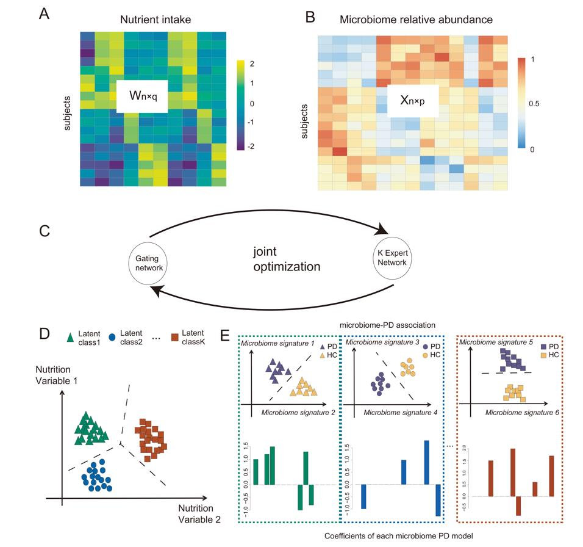

NEMoE use the nutrition data, microbiome data and health outcome as input to identify latent class based on the nutrients intake as well as the corresponding diet related microbiome signatures of disease.

In this vignette, we go through a 16S microbiome data of Parkinson’s disease to identify the latent classes shaped by nutrition intake and finding the microbiome signatures for each latent class.

```r
library(ggplot2)
library(NEMoE)
library(phyloseq)
```

# Gut microbiome and Parkinson’s disease

The `PD` dataset contain data from a gut microbiome-Parkinson’s disease study, the nutrition intake of each individual is also provided from food frequency questionnaire. We provide two type of the data(i.e. phyloseq object and a list) to construct input of NEMoE.

In this example, we will use NEMoE to identify two latent class of different nutrition pattern with altered microbiome-PD relationships and identify the related nutrition features for the latent class and microbiome signatures for each latent class.

```r
data("PD")
```

## Build the `NEMoE` object from list

First we build the `NEMoE` object, the input data to build `NEMoE` have three part: microbiome data, nutrition data and health outcome. The nutrition data can be either matrix or dataframe which each row is a sample and each column is a nutrient. The microbiome data can be either a list of table that contain several microbiome matrix where each row is a sample and each column is a taxa (at the level) or a `phyloseq`. The response is a vector of different health state.

In the following example, we build `NEMoE` object from list of microbiome data.

```r
Microbiome = PD$data_list$Microbiome
Nutrition = PD$data_list$Nutrition
Response = PD$data_list$Response
```

NEMoE object can also incorporate the parameters used in the fitting, including `K`,`lambda1`, `lambda2`, `alpha1`, `alpha2` and `cvParams`.

```r
NEMoE = NEMoE_buildFromList(Microbiome, Nutrition, Response, K = 2,
                            lambda1 = c(0.005, 0.01, 0.016, 0.023, 0.025),
                            lambda2 = 0.02, alpha1 = 0.5, alpha2 = 0.5,
                            cvParams = createCVList(g1 = 10, shrink = 0.4,
                                                    track = F))
```

### Fit the `NEMoE` object

Now using the `fitNEMoE` function, we can fit `NEMoE` object with the specified parameters in the `NEMoE` object.

```r
NEMoE = fitNEMoE(NEMoE)
```

```
#> Fitting NEMoE....
#> it: 0, PLL0:-499.79
#> it: 1, PLL:-498.912
#> it: 2, PLL:-498.135
#> it: 3, PLL:-497.429
#> it: 4, PLL:-496.733
#> it: 5, PLL:-495.999
#> it: 6, PLL:-495.196
#> it: 7, PLL:-494.288
#> it: 8, PLL:-493.227
#> it: 9, PLL:-491.953
#> it: 10, PLL:-490.378
#> it: 11, PLL:-488.453
#> it: 12, PLL:-486.091
#> it: 13, PLL:-483.381
#> it: 14, PLL:-480.661
#> it: 15, PLL:-478.076
#> it: 16, PLL:-475.773
#> it: 17, PLL:-473.822
#> it: 18, PLL:-472.299
#> it: 19, PLL:-471.153
#> it: 20, PLL:-470.36
#> it: 21, PLL:-469.868
#> it: 22, PLL:-469.542
#> it: 23, PLL:-469.326
#> it: 24, PLL:-469.179
#> it: 25, PLL:-469.077
#> it: 26, PLL:-469.008
#> it: 27, PLL:-468.962
#> it: 28, PLL:-468.93
#> it: 29, PLL:-468.906
#> it: 30, PLL:-468.888
#> it: 31, PLL:-468.872
#> it: 32, PLL:-468.859
#> it: 33, PLL:-468.848
#> it: 34, PLL:-468.838
#> it: 35, PLL:-468.829
#> it: 36, PLL:-468.821
#> it: 37, PLL:-468.813
#> it: 38, PLL:-468.806
```

[output cut: 15 more lines]

```
#> it: 54, PLL:-468.573
#> it: 55, PLL:-468.56
#> it: 56, PLL:-468.549
#> it: 57, PLL:-468.539
#> it: 58, PLL:-468.531
#> it: 59, PLL:-468.525
#> it: 60, PLL:-468.52
#> it: 61, PLL:-468.516
#> it: 62, PLL:-468.514
#> it: 63, PLL:-468.513
#> it: 64, PLL:-468.513
#> it: 65, PLL:-468.513
#> it: 66, PLL:-468.513
#> it: 67, PLL:-468.513
#> it: 68, PLL:-468.513
```

The fitted log-likelihood can be get from `getLL` function.

```r
getLL(NEMoE)
```

```
#>            LL_obs   PLL_obs LL_complete PLL_complete
#> Phylum  -90.21069 -117.7364   -147.4908    -175.0165
#> Order   -83.14621 -114.5389   -137.9087    -169.3014
#> Family  -82.83030 -115.6088   -139.6559    -172.4345
#> Genus   -78.56857 -113.8025   -144.2888    -179.5227
#> ASV     -64.70312 -109.2637   -133.2256    -177.7862
#> All    -399.45888 -468.5129   -702.5698    -771.6239
```

The corresponding coefficients in gating function, i.e. the effect size of each nutrition variables of their contribution to the different latent class can be obtained from `getCoef` function.

```r
coef.Gating <- getCoef(NEMoE)$coef.gating
```

These coefficients of gating network can be plotted by `plotGating` function.

```r
p_list <- plotGating(NEMoE)
```

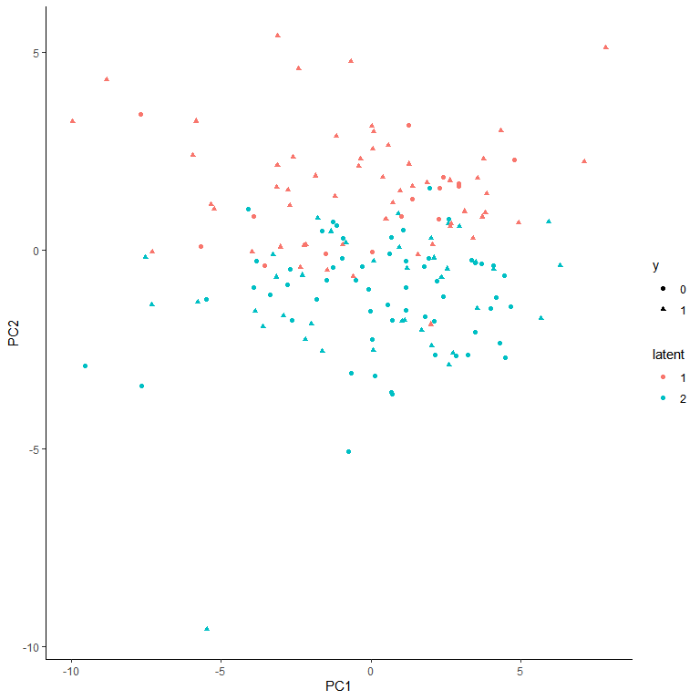

```r
print(p_list[[1]])
```

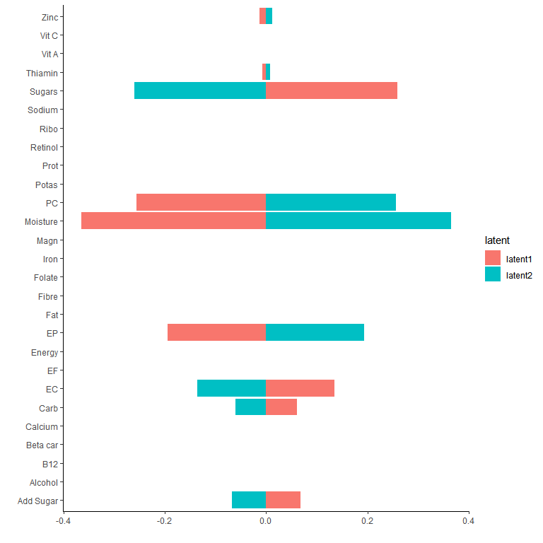

```r
print(p_list[[2]])
```

The corresponding coefficients in experts network, i.e. the effect size of each microbiome features of their contribution to health outcome (PD state here) in different latent class can be obtained from `getCoef` function.

```r
coef.Experts <- getCoef(NEMoE)$coef.experts
```

```r
p_list <- plotExperts(NEMoE)
```

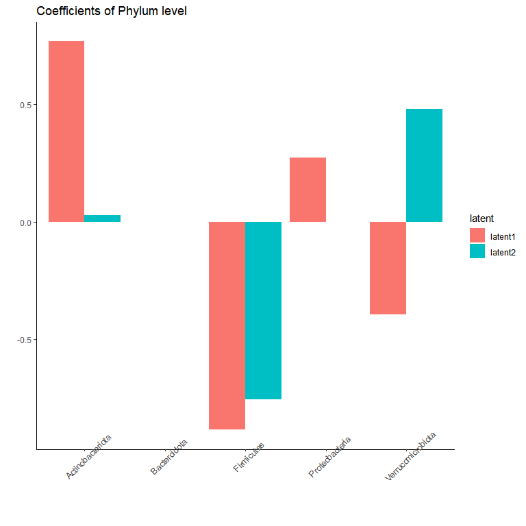

```r
print(p_list[[1]] + ggtitle("Coefficients of Phylum level") + theme(axis.text.x = element_text(angle = 45)))
```

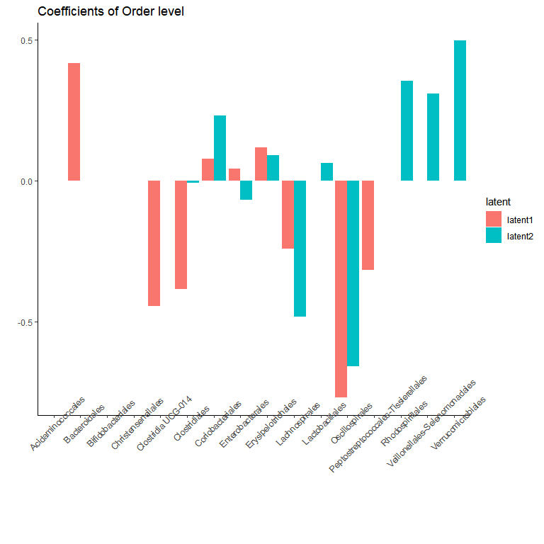

```r
print(p_list[[2]] + ggtitle("Coefficients of Order level") + theme(axis.text.x = element_text(angle = 45)))
```

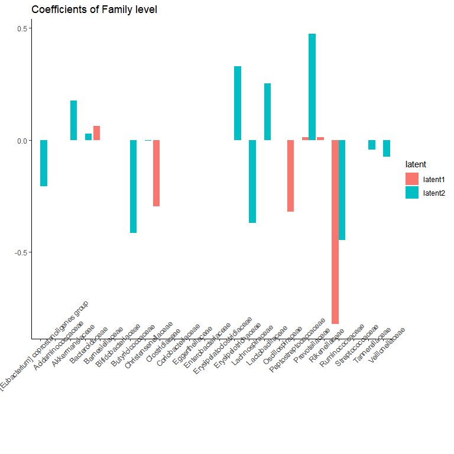

```r
print(p_list[[3]] + ggtitle("Coefficients of Family level") + theme(axis.text.x = element_text(angle = 45)))
```

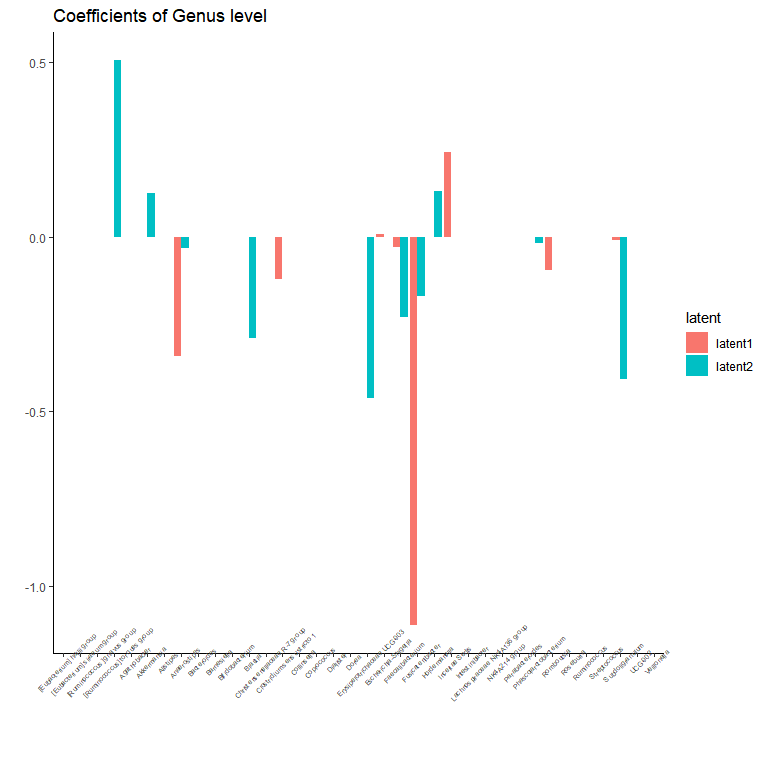

```r
print(p_list[[4]] + ggtitle("Coefficients of Genus level") + theme(axis.text.x = element_text(angle = 45, size = 5)))
```

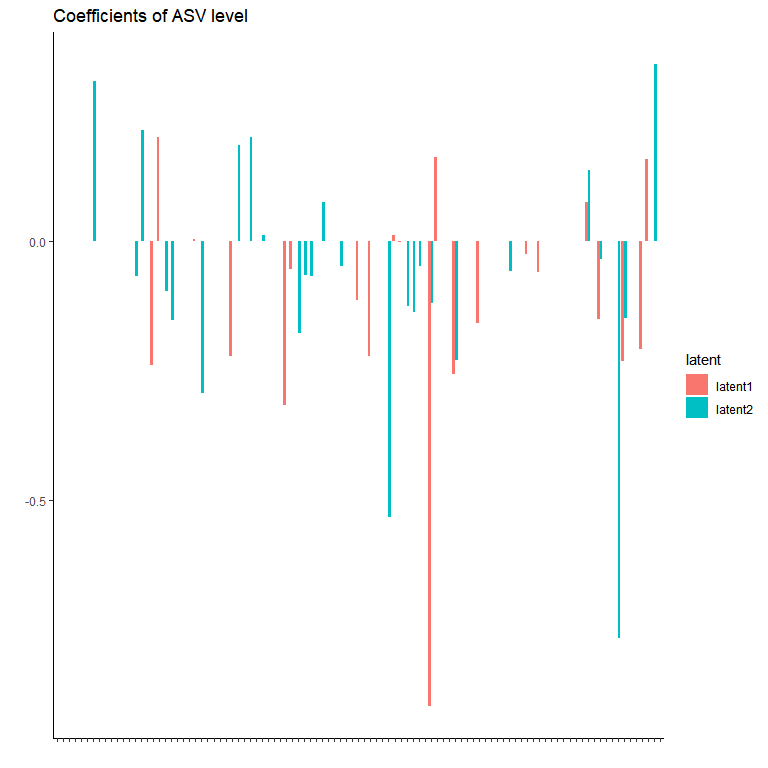

```r
print(p_list[[5]] + ggtitle("Coefficients of ASV level") + theme(axis.text.x = element_blank()))
```

### Single level `NEMoE`

`NEMoE` can also built based on single level data, we illustrated it using `Genus` level of the Microbiome-PD dataset.

```r
Microbiome_gen <- Microbiome$Genus
```

```r
NEMoE_gen = NEMoE_buildFromList(Microbiome_gen, Nutrition, Response, K = 2,
                            lambda1 = 0.028, lambda2 = 0.02,
                            alpha1 = 0.5, alpha2 = 0.5)
```

```r
NEMoE_gen <- fitNEMoE(NEMoE_gen, restart_it = 20)
```

```
#> Fitting NEMoE....
#> it: 0, PLL0:-100.266
#> it: 1, PLL:-99.6168
#> it: 2, PLL:-98.8656
#> it: 3, PLL:-98.0689
#> it: 4, PLL:-97.3039
#> it: 5, PLL:-96.6402
#> it: 6, PLL:-96.1162
#> it: 7, PLL:-95.7414
#> it: 8, PLL:-95.4918
#> it: 9, PLL:-95.3325
#> it: 10, PLL:-95.2354
#> it: 11, PLL:-95.1765
#> it: 12, PLL:-95.1401
#> it: 13, PLL:-95.1168
#> it: 14, PLL:-95.1014
#> it: 15, PLL:-95.0907
#> it: 16, PLL:-95.0832
#> it: 17, PLL:-95.0777
#> it: 18, PLL:-95.0735
#> it: 19, PLL:-95.0704
#> it: 20, PLL:-95.0679
#> it: 21, PLL:-95.066
#> it: 22, PLL:-95.0645
#> it: 23, PLL:-95.0633
#> it: 24, PLL:-95.0624
#> it: 25, PLL:-95.0616
#> it: 26, PLL:-95.0609
#> it: 27, PLL:-95.0604
#> it: 28, PLL:-95.06
#> it: 29, PLL:-95.0597
#> it: 30, PLL:-95.0594
#> it: 31, PLL:-95.0592
#> it: 32, PLL:-95.0591
#> it: 33, PLL:-95.0589
#> it: 34, PLL:-95.0588
#> it: 35, PLL:-95.0587
#> it: 36, PLL:-95.0587
#> it: 37, PLL:-95.0586
#> it: 38, PLL:-95.0586
#> it: 39, PLL:-95.0586
```

```r
p_list <- plotGating(NEMoE_gen)
```

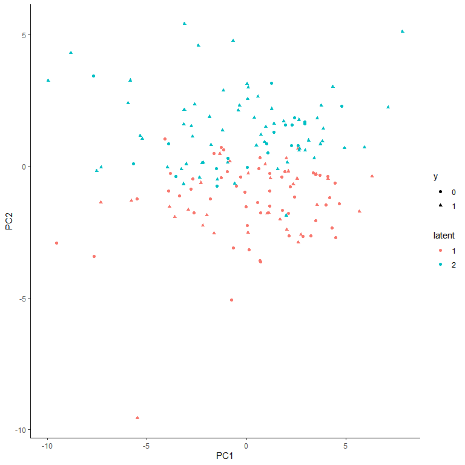

```r
print(p_list[[1]])
```

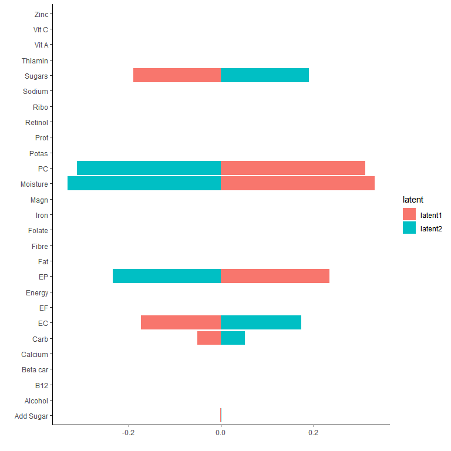

```r
print(p_list[[2]])
```

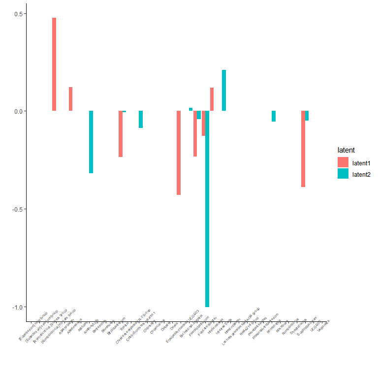

```r
p <- plotExperts(NEMoE_gen)[[1]]
p + theme(axis.text.x = element_text(angle = 45, size = 5))
```

## Build the `NEMoE` object from phyloseq

In parallel, `NEMoE` object can be built from `phyloseq` object from the microbiome counts data. `NEMoE` wrapper functions for TSS normalization and transformations of the counts data. Also which levels of the data incorporated in the data can be determined by user.

```r
sample_PD <- sample_data(PD$ps)
Response <- sample_PD$PD
Nutrition <- sample_PD[,-ncol(sample_PD)]
```

```r
NEMoE_ps <- NEMoE_buildFromPhyloseq(ps = PD$ps, Nutrition = scale(Nutrition),
                                 Response = Response,  K = 2,
                                 lambda1 = c(0.005, 0.014, 0.016, 0.023, 0.025),
                                 lambda2 = 0.02, alpha1 = 0.5, alpha2 = 0.5,
                                 filtParam = list(prev = 0.7, var = 1e-5),
                                 transParam = list(method = "asin"),
                                 taxLevel = c("Phylum","Order","Family",
                                              "Genus","ASV"))
```

The `NEMoE` object can also be fitted and visualized as it is in the previous section.

```r
NEMoE_ps <- fitNEMoE(NEMoE_ps)
```

```
#> Fitting NEMoE....
#> it: 0, PLL0:-494.62
#> it: 1, PLL:-493.94
#> it: 2, PLL:-493.284
#> it: 3, PLL:-492.686
#> it: 4, PLL:-492.094
#> it: 5, PLL:-491.481
#> it: 6, PLL:-490.83
#> it: 7, PLL:-490.129
#> it: 8, PLL:-489.357
#> it: 9, PLL:-488.485
#> it: 10, PLL:-487.511
#> it: 11, PLL:-486.401
#> it: 12, PLL:-485.14
#> it: 13, PLL:-483.711
#> it: 14, PLL:-482.088
#> it: 15, PLL:-480.307
#> it: 16, PLL:-478.45
#> it: 17, PLL:-476.66
#> it: 18, PLL:-475.071
#> it: 19, PLL:-473.713
#> it: 20, PLL:-472.585
#> it: 21, PLL:-471.669
#> it: 22, PLL:-470.943
#> it: 23, PLL:-470.389
#> it: 24, PLL:-469.979
#> it: 25, PLL:-469.67
#> it: 26, PLL:-469.436
#> it: 27, PLL:-469.256
#> it: 28, PLL:-469.116
#> it: 29, PLL:-469.004
#> it: 30, PLL:-468.932
#> it: 31, PLL:-468.885
#> it: 32, PLL:-468.852
#> it: 33, PLL:-468.827
#> it: 34, PLL:-468.81
#> it: 35, PLL:-468.797
#> it: 36, PLL:-468.789
#> it: 37, PLL:-468.782
#> it: 38, PLL:-468.777
#> it: 39, PLL:-468.773
#> it: 40, PLL:-468.77
#> it: 41, PLL:-468.767
#> it: 42, PLL:-468.766
#> it: 43, PLL:-468.764
#> it: 44, PLL:-468.763
#> it: 45, PLL:-468.762
#> it: 46, PLL:-468.761
#> it: 47, PLL:-468.761
#> it: 48, PLL:-468.761
#> it: 49, PLL:-468.76
#> it: 50, PLL:-468.76
#> it: 51, PLL:-468.76
#> it: 52, PLL:-468.76
```

```r
p_list <- plotGating(NEMoE_ps)
```

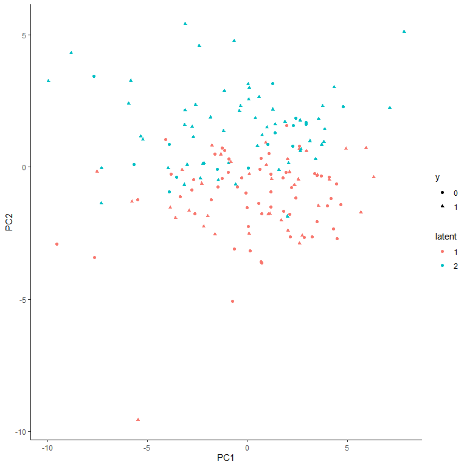

```r
print(p_list[[1]])
```

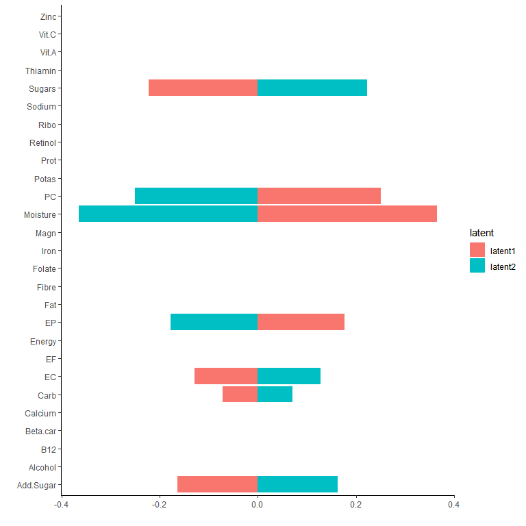

```r
print(p_list[[2]])
```

```r
p_list <- plotExperts(NEMoE_ps)
```

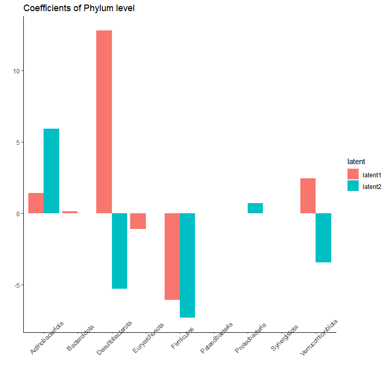

```r
print(p_list[[1]] + ggtitle("Coefficients of Phylum level") + theme(axis.text.x = element_text(angle = 45)))
```

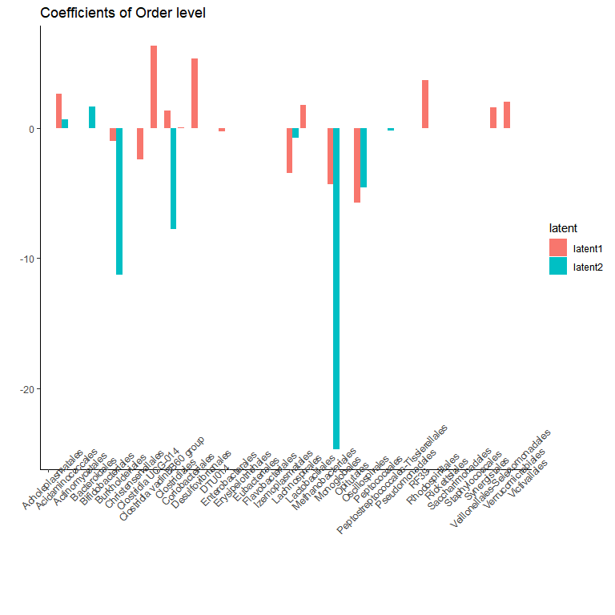

```r
print(p_list[[2]] + ggtitle("Coefficients of Order level") + theme(axis.text.x = element_text(angle = 45)))
```

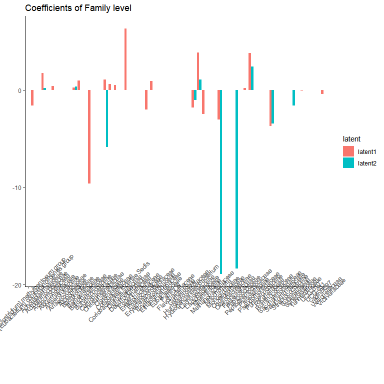

```r
print(p_list[[3]] + ggtitle("Coefficients of Family level") + theme(axis.text.x = element_text(angle = 45)))
```

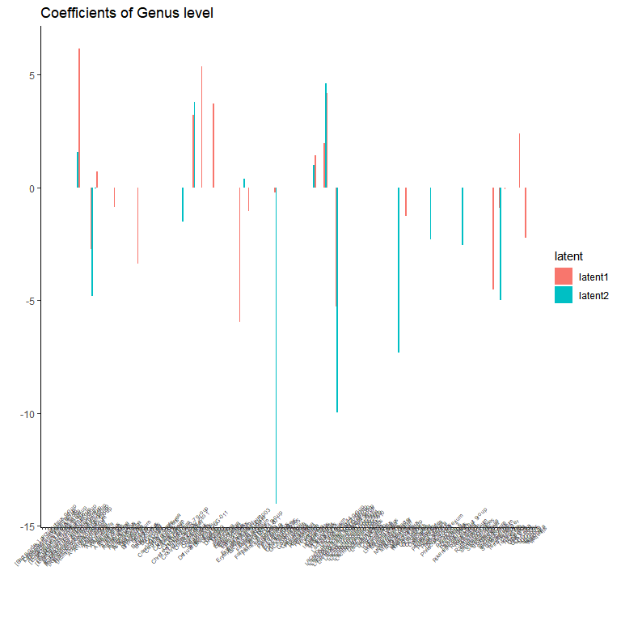

```r
print(p_list[[4]] + ggtitle("Coefficients of Genus level") + theme(axis.text.x = element_text(angle = 45, size = 5)))
```

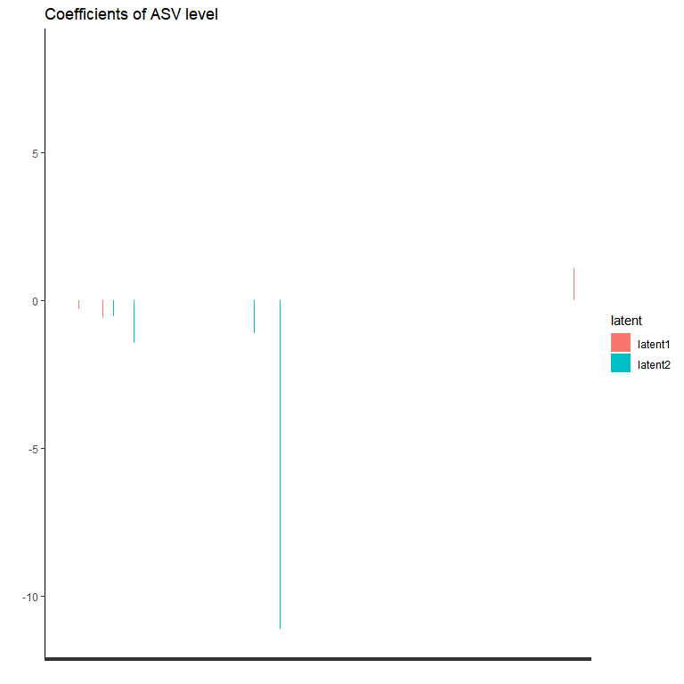

```r
print(p_list[[5]] + ggtitle("Coefficients of ASV level") + theme(axis.text.x = element_blank()))
```

## Evaluation and cross validation of NEMoE

We provide many metric including statistics such as `AIC`, `BIC` and `ICL` and cross validation metric such as cross validation accuracy and AUC.

```r
calcCriterion(NEMoE, "all")
```

```
#>            AIC       BIC     ICL1      ICL2      eBIC      mAIC      mBIC
#> [1,] -994.9178 -1301.066 -1601.14 -1907.288 -1668.063 -1034.918 -1328.765
#>         mICL1     mICL2  accuracy  D.square       TPR       TNR        F1
#> [1,] -1641.14 -1934.987 0.6845588 0.1405786 0.7790186 0.5601094 0.7341976
#>            auc
#> [1,] 0.7696813
```

Also the one can use this procedure to select parameters.

```r
NEMoE <- cvNEMoE(NEMoE)
```

The selected parameters obtained from the cross validation result can be used to fitting the model.

```r
lambda1_choose <- NEMoE@cvResult$lambda1_choose
lambda2_choose <- NEMoE@cvResult$lambda2_choose
```

```r
NEMoE <- setParam(NEMoE, lambda1 = lambda1_choose, lambda2 = lambda2_choose)
```

```r
NEMoE <- fitNEMoE(NEMoE)
```

```
#> Fitting NEMoE....
#> it: 0, PLL0:-501.013
#> it: 1, PLL:-500.212
#> it: 2, PLL:-499.472
#> it: 3, PLL:-498.733
#> it: 4, PLL:-497.929
#> it: 5, PLL:-497.022
#> it: 6, PLL:-496.004
#> it: 7, PLL:-494.839
#> it: 8, PLL:-493.45
#> it: 9, PLL:-491.807
#> it: 10, PLL:-489.977
#> it: 11, PLL:-488.07
#> it: 12, PLL:-486.185
#> it: 13, PLL:-484.433
#> it: 14, PLL:-482.941
#> it: 15, PLL:-481.805
#> it: 16, PLL:-480.969
#> it: 17, PLL:-480.343
#> it: 18, PLL:-479.852
#> it: 19, PLL:-479.398
#> it: 20, PLL:-478.804
#> it: 21, PLL:-478.021
#> it: 22, PLL:-477.311
#> it: 23, PLL:-476.739
#> it: 24, PLL:-476.297
#> it: 25, PLL:-476.022
#> it: 26, PLL:-475.841
#> it: 27, PLL:-475.714
#> it: 28, PLL:-475.621
#> it: 29, PLL:-475.549
#> it: 30, PLL:-475.487
#> it: 31, PLL:-475.443
#> it: 32, PLL:-475.407
#> it: 33, PLL:-475.374
#> it: 34, PLL:-475.341
#> it: 35, PLL:-475.309
#> it: 36, PLL:-475.274
#> it: 37, PLL:-475.236
#> it: 38, PLL:-475.192
```

[output cut: 32 more lines]

```
#> it: 71, PLL:-473.947
#> it: 72, PLL:-473.927
#> it: 73, PLL:-473.912
#> it: 74, PLL:-473.902
#> it: 75, PLL:-473.895
#> it: 76, PLL:-473.89
#> it: 77, PLL:-473.888
#> it: 78, PLL:-473.886
#> it: 79, PLL:-473.885
#> it: 80, PLL:-473.885
#> it: 81, PLL:-473.884
#> it: 82, PLL:-473.884
#> it: 83, PLL:-473.884
#> it: 84, PLL:-473.884
#> it: 85, PLL:-473.884
```

```r
p_list <- plotGating(NEMoE_ps)
```

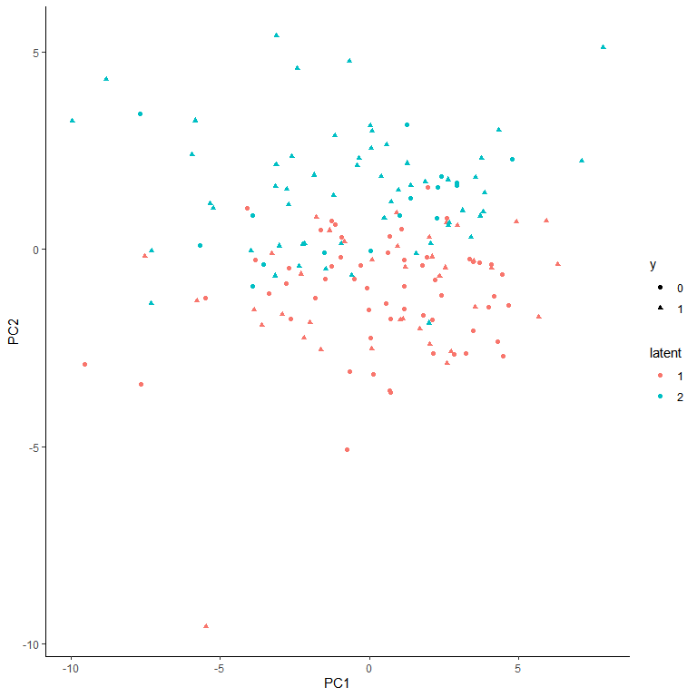

```r
print(p_list[[1]])
```

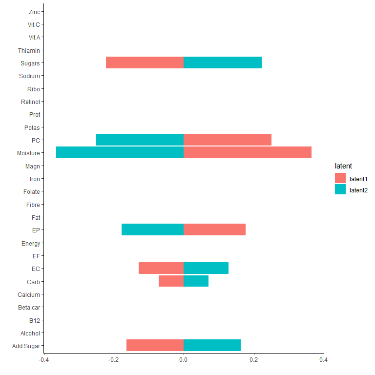

```r
print(p_list[[2]])
```

```r
p_list <- plotExperts(NEMoE)
```

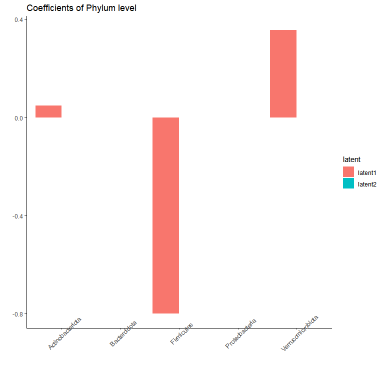

```r
print(p_list[[1]] + ggtitle("Coefficients of Phylum level") + theme(axis.text.x = element_text(angle = 45)))
```

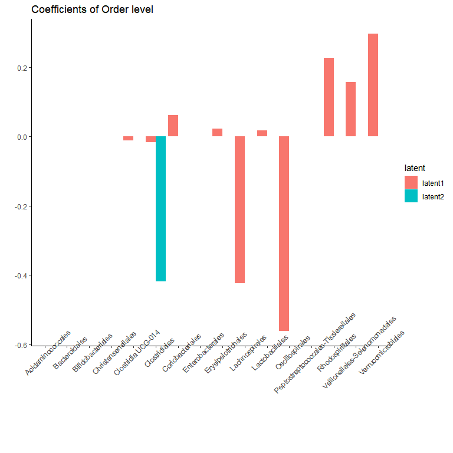

```r
print(p_list[[2]] + ggtitle("Coefficients of Order level") + theme(axis.text.x = element_text(angle = 45)))
```

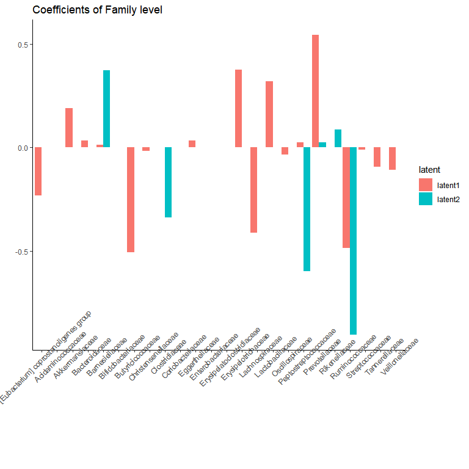

```r
print(p_list[[3]] + ggtitle("Coefficients of Family level") + theme(axis.text.x = element_text(angle = 45)))
```

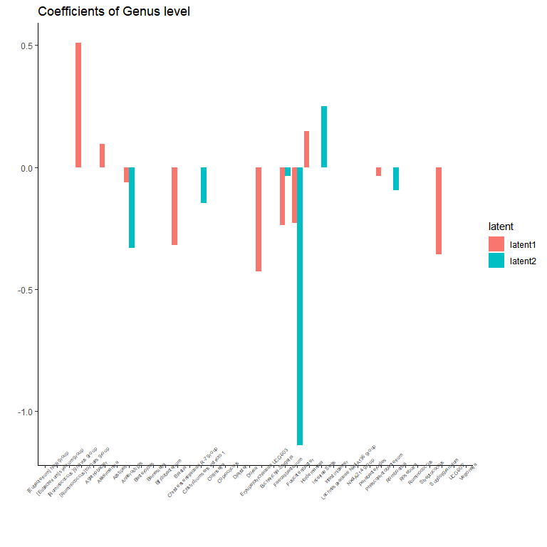

```r
print(p_list[[4]] + ggtitle("Coefficients of Genus level") + theme(axis.text.x = element_text(angle = 45, size = 5)))
```

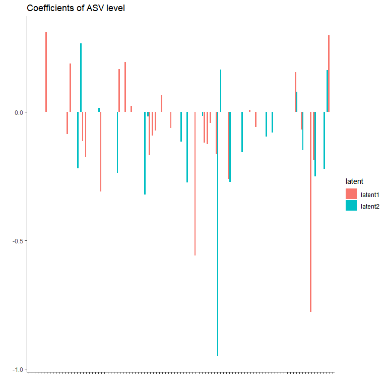

```r
print(p_list[[5]] + ggtitle("Coefficients of ASV level") + theme(axis.text.x = element_blank()))
```